# Housing_1 (2)

```python
import matplotlib.pyplot as plt
import numpy as np
import pandas as pd
import random
import seaborn as sns
%matplotlib inline
from sklearn.model_selection import train_test_split
from sklearn.preprocessing import LabelEncoder
```

## Load Data

**House price dataset**

```python
#Load the data
df= pd.read_csv("Housing.csv")
df.head(10)
```

|  | price | area | bedrooms | bathrooms | stories | mainroad | guestroom | basement | hotwaterheating | airconditioning | parking | prefarea | furnishingstatus |
| --- | --- | --- | --- | --- | --- | --- | --- | --- | --- | --- | --- | --- | --- |
| 0 | 13300000 | 7420 | 4 | 2 | 3 | yes | no | no | no | yes | 2 | yes | furnished |
| 1 | 12250000 | 8960 | 4 | 4 | 4 | yes | no | no | no | yes | 3 | no | furnished |
| 2 | 12250000 | 9960 | 3 | 2 | 2 | yes | no | yes | no | no | 2 | yes | semi-furnished |
| 3 | 12215000 | 7500 | 4 | 2 | 2 | yes | no | yes | no | yes | 3 | yes | furnished |
| 4 | 11410000 | 7420 | 4 | 1 | 2 | yes | yes | yes | no | yes | 2 | no | furnished |
| 5 | 10850000 | 7500 | 3 | 3 | 1 | yes | no | yes | no | yes | 2 | yes | semi-furnished |
| 6 | 10150000 | 8580 | 4 | 3 | 4 | yes | no | no | no | yes | 2 | yes | semi-furnished |
| 7 | 10150000 | 16200 | 5 | 3 | 2 | yes | no | no | no | no | 0 | no | unfurnished |
| 8 | 9870000 | 8100 | 4 | 1 | 2 | yes | yes | yes | no | yes | 2 | yes | furnished |
| 9 | 9800000 | 5750 | 3 | 2 | 4 | yes | yes | no | no | yes | 1 | yes | unfurnished |

# Display Data

```python
df.head()
```

|  | price | area | bedrooms | bathrooms | stories | mainroad | guestroom | basement | hotwaterheating | airconditioning | parking | prefarea | furnishingstatus |
| --- | --- | --- | --- | --- | --- | --- | --- | --- | --- | --- | --- | --- | --- |
| 0 | 13300000 | 7420 | 4 | 2 | 3 | yes | no | no | no | yes | 2 | yes | furnished |
| 1 | 12250000 | 8960 | 4 | 4 | 4 | yes | no | no | no | yes | 3 | no | furnished |
| 2 | 12250000 | 9960 | 3 | 2 | 2 | yes | no | yes | no | no | 2 | yes | semi-furnished |
| 3 | 12215000 | 7500 | 4 | 2 | 2 | yes | no | yes | no | yes | 3 | yes | furnished |
| 4 | 11410000 | 7420 | 4 | 1 | 2 | yes | yes | yes | no | yes | 2 | no | furnished |

**That housing dataset is composed of 545 observations and 13 features**

```python
df.shape
```

```
(545, 13)
```

# MAx and Lowest price

```python
print("Max price of house is: ", np.max(df['price']))
print("Lowest price of house is: ", np.min(df['price']))
```

```
Max price of house is:  13300000
Lowest price of house is:  1750000
```

# Names of the columns

```python
df.columns
```

```
Index(['price', 'area', 'bedrooms', 'bathrooms', 'stories', 'mainroad',
       'guestroom', 'basement', 'hotwaterheating', 'airconditioning',
       'parking', 'prefarea', 'furnishingstatus'],
      dtype='object')
```

# Type of Columns

```python
df.dtypes
```

```
price                int64
area                 int64
bedrooms             int64
bathrooms            int64
stories              int64
mainroad            object
guestroom           object
basement            object
hotwaterheating     object
airconditioning     object
parking              int64
prefarea            object
furnishingstatus    object
dtype: object
```

## Data Info Checking any Null Value

```python
df.info()
```

```
<class 'pandas.core.frame.DataFrame'>
RangeIndex: 545 entries, 0 to 544
Data columns (total 13 columns):
 #   Column            Non-Null Count  Dtype
---  ------            --------------  -----
 0   price             545 non-null    int64
 1   area              545 non-null    int64
 2   bedrooms          545 non-null    int64
 3   bathrooms         545 non-null    int64
 4   stories           545 non-null    int64
 5   mainroad          545 non-null    object
 6   guestroom         545 non-null    object
 7   basement          545 non-null    object
 8   hotwaterheating   545 non-null    object
 9   airconditioning   545 non-null    object
 10  parking           545 non-null    int64
 11  prefarea          545 non-null    object
 12  furnishingstatus  545 non-null    object
dtypes: int64(6), object(7)
memory usage: 55.5+ KB
```

```python
df.isnull().sum()
```

```
price               0
area                0
bedrooms            0
bathrooms           0
stories             0
mainroad            0
guestroom           0
basement            0
hotwaterheating     0
airconditioning     0
parking             0
prefarea            0
furnishingstatus    0
dtype: int64
```

**There is no missing value in the data set**

# Convert the yes into 1's and no into 0's

```python
#replace the columns having values yes and no
df['basement'].replace({'yes':1,'no':0},inplace=True)
df['guestroom'].replace({'yes':1,'no':0},inplace=True)
df['hotwaterheating'].replace({'yes':1,'no':0},inplace=True)
df['prefarea'].replace({'yes':1,'no':0},inplace=True)
df['airconditioning'].replace({'yes':1,'no':0},inplace=True)
df['mainroad'].replace({'yes':1,'no':0},inplace=True)
```

# Dataframe after the replacement of 1's and 0's

```python
df
```

|  | price | area | bedrooms | bathrooms | stories | mainroad | guestroom | basement | hotwaterheating | airconditioning | parking | prefarea | furnishingstatus |
| --- | --- | --- | --- | --- | --- | --- | --- | --- | --- | --- | --- | --- | --- |
| 0 | 13300000 | 7420 | 4 | 2 | 3 | 1 | 0 | 0 | 0 | 1 | 2 | 1 | furnished |
| 1 | 12250000 | 8960 | 4 | 4 | 4 | 1 | 0 | 0 | 0 | 1 | 3 | 0 | furnished |
| 2 | 12250000 | 9960 | 3 | 2 | 2 | 1 | 0 | 1 | 0 | 0 | 2 | 1 | semi-furnished |
| 3 | 12215000 | 7500 | 4 | 2 | 2 | 1 | 0 | 1 | 0 | 1 | 3 | 1 | furnished |
| 4 | 11410000 | 7420 | 4 | 1 | 2 | 1 | 1 | 1 | 0 | 1 | 2 | 0 | furnished |
| ... | ... | ... | ... | ... | ... | ... | ... | ... | ... | ... | ... | ... | ... |
| 540 | 1820000 | 3000 | 2 | 1 | 1 | 1 | 0 | 1 | 0 | 0 | 2 | 0 | unfurnished |
| 541 | 1767150 | 2400 | 3 | 1 | 1 | 0 | 0 | 0 | 0 | 0 | 0 | 0 | semi-furnished |
| 542 | 1750000 | 3620 | 2 | 1 | 1 | 1 | 0 | 0 | 0 | 0 | 0 | 0 | unfurnished |
| 543 | 1750000 | 2910 | 3 | 1 | 1 | 0 | 0 | 0 | 0 | 0 | 0 | 0 | furnished |
| 544 | 1750000 | 3850 | 3 | 1 | 2 | 1 | 0 | 0 | 0 | 0 | 0 | 0 | unfurnished |

545 rows × 13 columns

# Statistical Discripton about dataset

**Convert Categorical Dataset into Number using LabelEncoder**

```python
le = LabelEncoder()  # Call the LabelEncoder class
label = le.fit_transform(df['furnishingstatus'])  # Fit and transform
label = pd.DataFrame(label,  columns=['output'])
```

```python
all_category = df['furnishingstatus'].drop_duplicates()

dict(zip(all_category, le.transform(all_category)))
```

```
{'furnished': 0, 'semi-furnished': 1, 'unfurnished': 2}
```

```python
df_house_price = pd.concat([df, label], axis=1)
df_house_price.drop(columns=["furnishingstatus"] ,axis = 1, inplace=True)
```

```python
df_house_price
```

|  | price | area | bedrooms | bathrooms | stories | mainroad | guestroom | basement | hotwaterheating | airconditioning | parking | prefarea | output |
| --- | --- | --- | --- | --- | --- | --- | --- | --- | --- | --- | --- | --- | --- |
| 0 | 13300000 | 7420 | 4 | 2 | 3 | 1 | 0 | 0 | 0 | 1 | 2 | 1 | 0 |
| 1 | 12250000 | 8960 | 4 | 4 | 4 | 1 | 0 | 0 | 0 | 1 | 3 | 0 | 0 |
| 2 | 12250000 | 9960 | 3 | 2 | 2 | 1 | 0 | 1 | 0 | 0 | 2 | 1 | 1 |
| 3 | 12215000 | 7500 | 4 | 2 | 2 | 1 | 0 | 1 | 0 | 1 | 3 | 1 | 0 |
| 4 | 11410000 | 7420 | 4 | 1 | 2 | 1 | 1 | 1 | 0 | 1 | 2 | 0 | 0 |
| ... | ... | ... | ... | ... | ... | ... | ... | ... | ... | ... | ... | ... | ... |
| 540 | 1820000 | 3000 | 2 | 1 | 1 | 1 | 0 | 1 | 0 | 0 | 2 | 0 | 2 |
| 541 | 1767150 | 2400 | 3 | 1 | 1 | 0 | 0 | 0 | 0 | 0 | 0 | 0 | 1 |
| 542 | 1750000 | 3620 | 2 | 1 | 1 | 1 | 0 | 0 | 0 | 0 | 0 | 0 | 2 |
| 543 | 1750000 | 2910 | 3 | 1 | 1 | 0 | 0 | 0 | 0 | 0 | 0 | 0 | 0 |
| 544 | 1750000 | 3850 | 3 | 1 | 2 | 1 | 0 | 0 | 0 | 0 | 0 | 0 | 2 |

545 rows × 13 columns

# Data Describtion

```python
#numeric data description
df_house_price.describe()
```

|  | price | area | bedrooms | bathrooms | stories | mainroad | guestroom | basement | hotwaterheating | airconditioning | parking | prefarea | output |
| --- | --- | --- | --- | --- | --- | --- | --- | --- | --- | --- | --- | --- | --- |
| count | 5.450000e+02 | 545.000000 | 545.000000 | 545.000000 | 545.000000 | 545.000000 | 545.000000 | 545.000000 | 545.000000 | 545.000000 | 545.000000 | 545.000000 | 545.000000 |
| mean | 4.766729e+06 | 5150.541284 | 2.965138 | 1.286239 | 1.805505 | 0.858716 | 0.177982 | 0.350459 | 0.045872 | 0.315596 | 0.693578 | 0.234862 | 1.069725 |
| std | 1.870440e+06 | 2170.141023 | 0.738064 | 0.502470 | 0.867492 | 0.348635 | 0.382849 | 0.477552 | 0.209399 | 0.465180 | 0.861586 | 0.424302 | 0.761373 |
| min | 1.750000e+06 | 1650.000000 | 1.000000 | 1.000000 | 1.000000 | 0.000000 | 0.000000 | 0.000000 | 0.000000 | 0.000000 | 0.000000 | 0.000000 | 0.000000 |
| 25% | 3.430000e+06 | 3600.000000 | 2.000000 | 1.000000 | 1.000000 | 1.000000 | 0.000000 | 0.000000 | 0.000000 | 0.000000 | 0.000000 | 0.000000 | 0.000000 |
| 50% | 4.340000e+06 | 4600.000000 | 3.000000 | 1.000000 | 2.000000 | 1.000000 | 0.000000 | 0.000000 | 0.000000 | 0.000000 | 0.000000 | 0.000000 | 1.000000 |
| 75% | 5.740000e+06 | 6360.000000 | 3.000000 | 2.000000 | 2.000000 | 1.000000 | 0.000000 | 1.000000 | 0.000000 | 1.000000 | 1.000000 | 0.000000 | 2.000000 |
| max | 1.330000e+07 | 16200.000000 | 6.000000 | 4.000000 | 4.000000 | 1.000000 | 1.000000 | 1.000000 | 1.000000 | 1.000000 | 3.000000 | 1.000000 | 2.000000 |

# Check the outliers

## Z-score is a good way of finding the outliers

```python
from scipy import stats
import numpy as np
z = np.abs(stats.zscore(df_house_price))
print(z)
```

```
[[4.56636513 1.04672629 1.40341936 ... 1.51769249 1.80494113 1.40628573]
 [4.00448405 1.75700953 1.40341936 ... 2.67940935 0.55403469 1.40628573]
 [4.00448405 2.21823241 0.04727831 ... 1.51769249 1.80494113 0.09166185]
 ...
 [1.61432675 0.70592066 1.30886273 ... 0.80574124 0.55403469 1.22296203]
 [1.61432675 1.03338891 0.04727831 ... 0.80574124 0.55403469 1.40628573]
 [1.61432675 0.5998394  0.04727831 ... 0.80574124 0.55403469 1.22296203]]
```

## If the Value of of Variable is Greater then 3 it is consider as outlier

```python
threshold = 3
print(np.where(z > 3))
```

```
(array([  0,   1,   1,   2,   3,   4,   5,   5,   6,   7,   7,  10,  11,
        11,  13,  20,  28,  33,  36,  66,  66,  69,  74,  75,  80,  84,
        89, 109, 112, 125, 143, 153, 165, 195, 196, 211, 270, 290, 298,
       321, 334, 350, 363, 364, 378, 395, 403, 464, 490, 499, 530]), array([0, 0, 3, 0, 0, 0, 0, 3, 3, 1, 3, 1, 3, 8, 8, 8, 8, 3, 8, 1, 8, 1,
       8, 8, 8, 8, 3, 8, 2, 1, 8, 3, 8, 3, 8, 1, 8, 3, 8, 8, 8, 8, 8, 8,
       8, 2, 1, 8, 8, 3, 8]))
```

```python
df_house_price[(np.abs(stats.zscore(df_house_price)) < 3).all(axis=1)]
```

|  | price | area | bedrooms | bathrooms | stories | mainroad | guestroom | basement | hotwaterheating | airconditioning | parking | prefarea | output |
| --- | --- | --- | --- | --- | --- | --- | --- | --- | --- | --- | --- | --- | --- |
| 8 | 9870000 | 8100 | 4 | 1 | 2 | 1 | 1 | 1 | 0 | 1 | 2 | 1 | 0 |
| 9 | 9800000 | 5750 | 3 | 2 | 4 | 1 | 1 | 0 | 0 | 1 | 1 | 1 | 2 |
| 12 | 9310000 | 6550 | 4 | 2 | 2 | 1 | 0 | 0 | 0 | 1 | 1 | 1 | 1 |
| 14 | 9240000 | 7800 | 3 | 2 | 2 | 1 | 0 | 0 | 0 | 0 | 0 | 1 | 1 |
| 15 | 9100000 | 6000 | 4 | 1 | 2 | 1 | 0 | 1 | 0 | 0 | 2 | 0 | 1 |
| ... | ... | ... | ... | ... | ... | ... | ... | ... | ... | ... | ... | ... | ... |
| 540 | 1820000 | 3000 | 2 | 1 | 1 | 1 | 0 | 1 | 0 | 0 | 2 | 0 | 2 |
| 541 | 1767150 | 2400 | 3 | 1 | 1 | 0 | 0 | 0 | 0 | 0 | 0 | 0 | 1 |
| 542 | 1750000 | 3620 | 2 | 1 | 1 | 1 | 0 | 0 | 0 | 0 | 0 | 0 | 2 |
| 543 | 1750000 | 2910 | 3 | 1 | 1 | 0 | 0 | 0 | 0 | 0 | 0 | 0 | 0 |
| 544 | 1750000 | 3850 | 3 | 1 | 2 | 1 | 0 | 0 | 0 | 0 | 0 | 0 | 2 |

499 rows × 13 columns

## Exploratory Analysis of Data

# 1- Show the visualization of numeric data columns

**We will create some simple plot for visualizing the data**

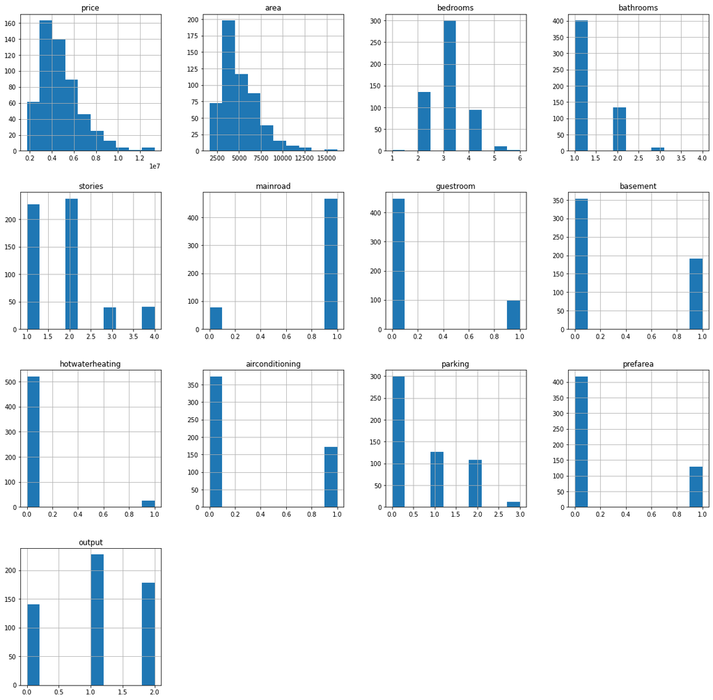

```python
fig=plt.figure(figsize=(12,6))
df_house_price.hist(figsize = (20, 20))
plt.show()
```

# Distribution of Price

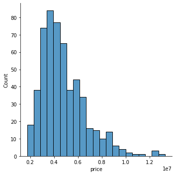

```python
fig=plt.figure(figsize=(13,5))
sns.displot(df_house_price['price'])
```

### Graph Telling Which House is More Prefered

### {'furnished': 0, 'semi-furnished': 1, 'unfurnished': 2}

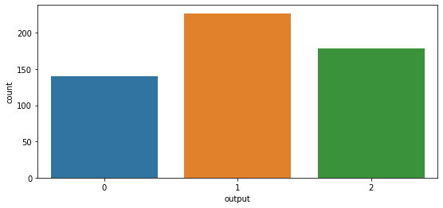

```python
fig=plt.figure(figsize=(9,4))
sns.countplot(df_house_price['output'])
```

# Total Number of Furnished, Semi-Furnished and Unfurnished House

```python
df_house_price['output'].value_counts().to_frame()
```

|  | output |
| --- | --- |
| 1 | 227 |
| 2 | 178 |
| 0 | 140 |

# 5-Count the total number of guestrooms are available and which are unavialable.

```python
# NO== houses without guestrooms.....YES== houses with guestrooms
df_house_price['guestroom'].value_counts().to_frame()
```

|  | guestroom |
| --- | --- |
| 0 | 448 |
| 1 | 97 |

# 6- Show by graph the houses with guest rooms and without guest rooms.

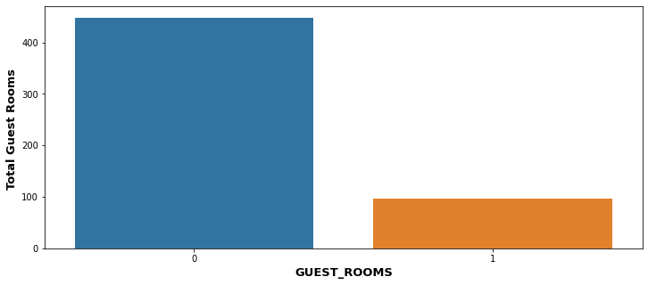

```python
# "yes" is  for the guestrooms are in the houses and "no" is for unavailibilty of guestrooms in the respective house
plt.rcParams['figure.figsize']=(12,5)
sns.countplot(df_house_price['guestroom'])
plt.xlabel('GUEST_ROOMS',fontweight='bold',fontsize=13)
plt.ylabel('Total Guest Rooms ',fontweight='bold',fontsize=13)
plt.show()
```

# 7- Distrubtion of House Stories w.r.t to Furnished, Unfurnished and semi-furnished

### Baiscally telling how many storeis house are F/SF/UF

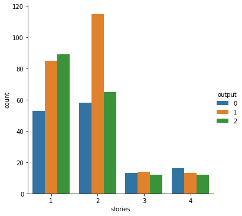

```python
fig=plt.figure(figsize=(12,5))
sns.catplot('stories',data=df_house_price,hue='output',kind='count')
```

# Analyse by numbering

```python
df_house_price['stories'].value_counts().to_frame()
```

|  | stories |
| --- | --- |
| 2 | 238 |
| 1 | 227 |
| 4 | 41 |
| 3 | 39 |

# 8- Show by graph total number of bedrooms to see the most selling number of bedrooms

```python
df_house_price
```

|  | price | area | bedrooms | bathrooms | stories | mainroad | guestroom | basement | hotwaterheating | airconditioning | parking | prefarea | output |
| --- | --- | --- | --- | --- | --- | --- | --- | --- | --- | --- | --- | --- | --- |
| 0 | 13300000 | 7420 | 4 | 2 | 3 | 1 | 0 | 0 | 0 | 1 | 2 | 1 | 0 |
| 1 | 12250000 | 8960 | 4 | 4 | 4 | 1 | 0 | 0 | 0 | 1 | 3 | 0 | 0 |
| 2 | 12250000 | 9960 | 3 | 2 | 2 | 1 | 0 | 1 | 0 | 0 | 2 | 1 | 1 |
| 3 | 12215000 | 7500 | 4 | 2 | 2 | 1 | 0 | 1 | 0 | 1 | 3 | 1 | 0 |
| 4 | 11410000 | 7420 | 4 | 1 | 2 | 1 | 1 | 1 | 0 | 1 | 2 | 0 | 0 |
| ... | ... | ... | ... | ... | ... | ... | ... | ... | ... | ... | ... | ... | ... |
| 540 | 1820000 | 3000 | 2 | 1 | 1 | 1 | 0 | 1 | 0 | 0 | 2 | 0 | 2 |
| 541 | 1767150 | 2400 | 3 | 1 | 1 | 0 | 0 | 0 | 0 | 0 | 0 | 0 | 1 |
| 542 | 1750000 | 3620 | 2 | 1 | 1 | 1 | 0 | 0 | 0 | 0 | 0 | 0 | 2 |
| 543 | 1750000 | 2910 | 3 | 1 | 1 | 0 | 0 | 0 | 0 | 0 | 0 | 0 | 0 |
| 544 | 1750000 | 3850 | 3 | 1 | 2 | 1 | 0 | 0 | 0 | 0 | 0 | 0 | 2 |

545 rows × 13 columns

## Total House

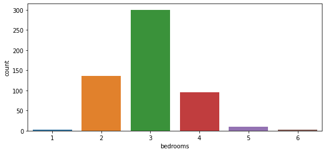

```python
fig=plt.figure(figsize=(9,4))
sns.countplot(df_house_price['bedrooms'])
```

## Cross Tab of Number of Bedroom in Each Storeis House

```python
pd.crosstab([df_house_price["bedrooms"]], df_house_price["stories"],
            margins = True).style.background_gradient(cmap = "summer_r")
```

| stories bedrooms | 1 | 2 | 3 | 4 | All |
| --- | --- | --- | --- | --- | --- |
| 1 | 2 | 0 | 0 | 0 | 2 |
| 2 | 115 | 20 | 0 | 1 | 136 |
| 3 | 101 | 143 | 31 | 25 | 300 |
| 4 | 8 | 65 | 7 | 15 | 95 |
| 5 | 1 | 8 | 1 | 0 | 10 |
| 6 | 0 | 2 | 0 | 0 | 2 |
| All | 227 | 238 | 39 | 41 | 545 |